# Week 5-6: HDBSCAN Clustering

SURA 2022

Shih-Ting (Cindy) Huang

2022-07-06

## HDBSCAN

### Finding the best parameters

There are several metrics for evaluating the quality of clusters. The following are some common ones and an evaluation:

- CDbw: considers multiple representative points per cluster, but it means that we have to introduce a parameter for defining the number of points
  - cohesion: within-cluster density change
  - compactness: average within-cluster density
  - separation: inter-cluster density
  - CDbw index: relative validity index that takes into consideration all of the aforementioned metrics
- DBCV: evaluates clusters by comparing the highest density between clusters and the lowest density in clusters

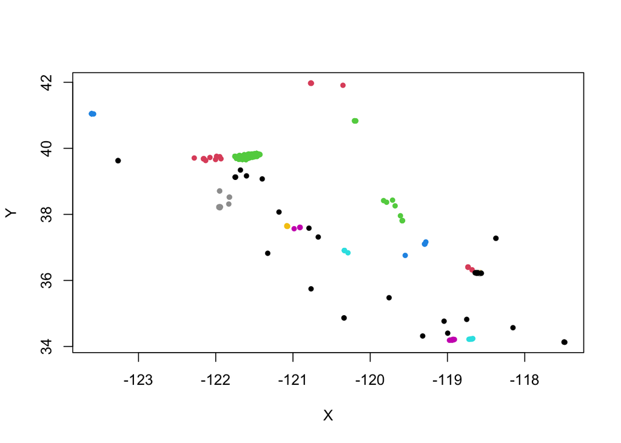

## Cluster Visualization

In HDBSCAN, clusters are arbitrarily shape. Hence, we cannot obtain a cluster “centroid” effectively. Hence, we still display all the points colored by their clusters in the visualization.

[interactive chart not shown]

## Cluster FRP: Summary

A summary of clusters for 11/08/2018

| Cluster | Average FRP | Variance |
| --- | --- | --- |
| 1 | 2.0753 | 0.5137 |
| 2 | 31.8651 | 1984.3889 |
| 3 | NaN | NA |
| 4 | NaN | NA |
| 5 | NaN | NA |
| 6 | 3.7036 | 9.9555 |
| 7 | 16.6623 | 312.9396 |
| 8 | 20.3447 | 884.1141 |
| 9 | 1.8465 | 1.1100 |
| 10 | 4.2535 | 2.6519 |
| 11 | 1.1526 | 0.2596 |
| 12 | 9.1422 | 61.9808 |
| 13 | 7.3448 | 62.7275 |
| 14 | 24.1770 | 403.1557 |
| 15 | 14.9712 | 106.6972 |
| 16 | 2.4090 | 0.5152 |
| 17 | 2.3319 | 2.0031 |
| 18 | 134.3567 | 85643.1991 |

## PostGIS

- PostgreSQL but with spatial functionality
- [Resource for setting up](https://towardsdatascience.com/spatial-data-science-with-postgresql-postgis-2f941c8c367a)

## References:

1. Moulavi, Davoud & A Jaskowiak, Pablo & Campello, Ricardo & Zimek, Arthur & Sander, Joerg. (2014). Density-Based Clustering Validation. 10.1137/1.9781611973440.96.

[Access the paper here](https://www.researchgate.net/publication/260333211_Density-Based_Clustering_Validation)

2. [A density-based cluster validity approach using multi-representatives](https://www.sciencedirect.com/science/article/pii/S0167865508000020)